# Playing with Data II: Visualization

Kristin Bail

July 14, 2021

Hi everyone,

This is another of your friendly neighborhood data visualizers, Kristin. Previous sessions have acquainted you with some methods for getting to know your data. In this portion of the math camp series, we’ll be discussing some of the first steps to take if you want to display it graphically.

Data analysis is one of the core parts of your graduate training, and growing your data visualization skills will help you understand your data’s structure and how to best analyze it. Good data visualization also helps make your research more accessible to other scholars and the general public, displaying the relationships you detect in an easy to follow way. The glut of data available to social and data scientists has only increased the importance of being able to “show your data” in a useful and clear way.

Data science and R coding can be intimidating, but I hope to equip you with some basic tools that will ease you in to the data visualization process. With this in mind, this document is divided into three basic parts: 1) some first steps we can take when looking for patterns in our data; 2) basic data visualization; and 3) visualizing regression results. These parts ascend in order of difficulty. If you feel comfortable with some of the basics of base R visualization, feel free to skip to the later sections. And if you don’t feel up to the more complicated stuff and want to keep it simple, save the later portions for another day!

In part 1 I outline some of the most basic ways we display our data and the information we can glean from doing so. Part 2 uses a basic dataset in R, ‘iris,’ to try out some different approaches to graphic visualization. The third part pairs the same dataset with regression analysis to generate regression tables and plot regression coefficient tables in fancy ways. As it is difficult to quickly glean meaning from regression tables, the latter is especially applicable for presentations of all sorts.

## 1. Why Visualize?

### Getting to know your data

Political science researchers use data from many sources and on diverse subjects: cross-national survey data from Afrobarometer, World Bank data about GDP growth and poverty rates, or perhaps original data collected through the PS subject pool. Whichever data you use, among the first things you’ll want to do is see what the data look like. While values such as the mean, standard deviation, or correlation coefficients can convey important information about the spread of the data, seeing the data helps us understand other important factors such as the distribution or the presence of outliers.

Let’s first start with some basic commands. As you’ve probably seen in other sessions, I will use a # to tell R what is code it should pay attention to and what it should ignore.

Let’s first see the entire dataset we are using today, `iris.’ The help() command opens a description in the R environment on the right, telling us that the dataset contains measurements in centimeters of the variables for 50 flowers from each of three species of flowers.

```r
#help(iris)

#This code will open a new window with a spreadsheet showing the dataset. You see five columns and 150 rows
View(iris)

colnames(iris) # will show the names of columns. This is helpful when you have hundreds of columns in your dataset
```

```
## [1] "Sepal.Length" "Sepal.Width"  "Petal.Length" "Petal.Width"
## [5] "Species"
```

```r
str(iris) # conveys the structure of the dataset, useful when you want to know the type (`numeric', `factor', `character') of each variable. This command tells us that we have 150 observations and that four #variables are numeric and one is a factor with three levels.
```

```
## 'data.frame':    150 obs. of  5 variables:
##  $ Sepal.Length: num  5.1 4.9 4.7 4.6 5 5.4 4.6 5 4.4 4.9 ...
##  $ Sepal.Width : num  3.5 3 3.2 3.1 3.6 3.9 3.4 3.4 2.9 3.1 ...
##  $ Petal.Length: num  1.4 1.4 1.3 1.5 1.4 1.7 1.4 1.5 1.4 1.5 ...
##  $ Petal.Width : num  0.2 0.2 0.2 0.2 0.2 0.4 0.3 0.2 0.2 0.1 ...
##  $ Species     : Factor w/ 3 levels "setosa","versicolor",..: 1 1 1 1 1 1 1 1 1 1 ...
```

While these base R commands are often enough to tell us what we need or want to know, other R packages do it prettier. For example, “stargazer” is a good tool to show descriptive statistics and also regression tables.

```r
#Remove the # from the line of code below if you don't already have the stargazer package installed
#install.packages("stargazer")

stargazer::stargazer(iris, type = "text")
```

```
##
## =============================================================
## Statistic     N  Mean  St. Dev.  Min  Pctl(25) Pctl(75)  Max
## -------------------------------------------------------------
## Sepal.Length 150 5.843  0.828   4.300  5.100    6.400   7.900
## Sepal.Width  150 3.057  0.436   2.000  2.800    3.300   4.400
## Petal.Length 150 3.758  1.765   1.000  1.600    5.100   6.900
## Petal.Width  150 1.199  0.762   0.100  0.300    1.800   2.500
## -------------------------------------------------------------
```

## 2. Basic Plots

Time to really visualize! Often how we analyze data hinges on how the data are distributed. Is the distribution normal or skewed? Are the data scattered across a wide range of values or clumped on one end of the scale? Histograms help us answer that question. Using the hist() command generates a histogram that shows us how many observations fall within a specific range of values. Let’s say we want to see the variation in petal width or sepal length across the iris sample.

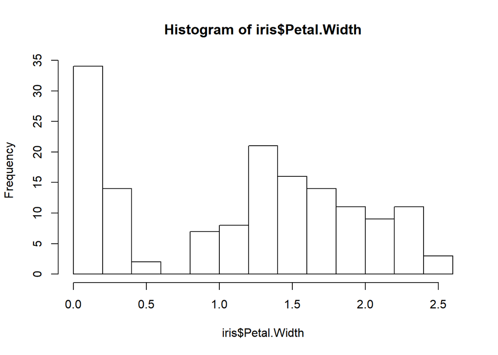

```r
hist(iris$Petal.Width) #Using $ designates which column in the dataset R is using
```

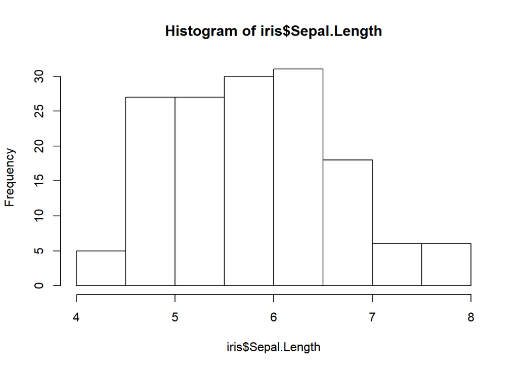

```r
#Or sepal length
hist(iris$Sepal.Length)
```

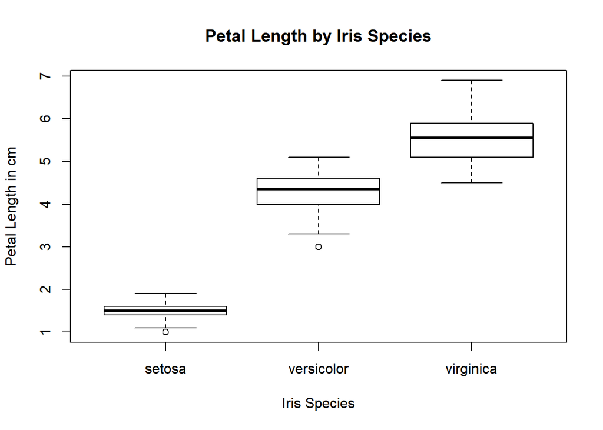

```r
#The code below gives us a basic plot conveying variation in petal length by iris species
#boxplot(iris$Petal.Length~iris$Species)

#Adding a couple of parameters to our plots changes the axis labels and makes the whole thing look better:
boxplot(iris$Petal.Length~iris$Species, main="Petal Length by Iris Species",
        xlab = "Iris Species", ylab = "Petal Length in cm")
```

The above box plot indicates that across species, some irises are much smaller on average than others. We can also observe that species such as the virginica have a much wider range of petal lengths.

One of the things we’re often most interested in is the strength of association between two variables. Let’s say that we have a **hypothesis** that petal length may be consequential for the width of a petal. So we think maybe petal length might help explain petal width. We want to know if there is a statistically significant relationship between the two such that the observed petal measurements can’t be random, or the product of chance. Generating a scatter plot is typically a first step in discerning the relationship between variables because they position observations along a plane in accordance to numeric variables. From a cursory assessment of the scatter plot below, it seems as though there is a positive relationship between petal width and length, indicating our hypothesis *might* be right.

The code below gives you two ways to make similar scatter plots.

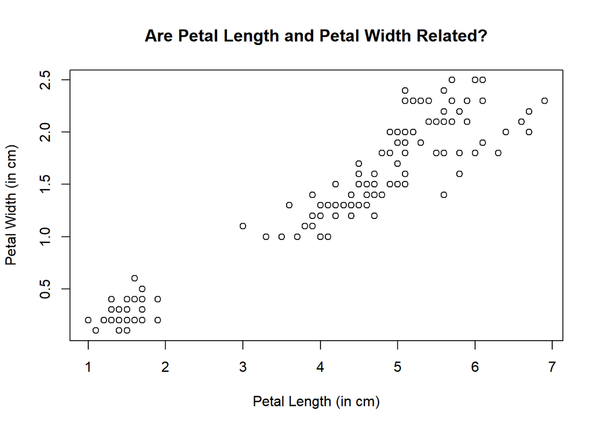

```r
#with(iris,plot(Petal.Length~Petal.Width)) # This will create a scatterplot on the lower-right panel of R studio. OR:

# You can specify your x and y in `plot()' command.
plot(x=iris$Petal.Length, y=iris$Petal.Width, main = "Are Petal Length and Petal Width Related?",
     xlab = "Petal Length (in cm)", ylab = "Petal Width (in cm)")
```

### Practice

1. Use the hist() command to plot the distribution of the variable iris$Sepal.Width. Make sure to add a title and axis labels

```r
#hist()
```

2. Make a scatter plot of the data using the plot() command, this time putting sepal length on the y-axis and sepal length on the x. Be sure to provide accurate and clear labels.

```r
#plot()
```

## 3. Visualizing Regression Results

### 3.1 Bivariate Relationships

The scatter plot we made above gives a fair idea of where the data fall, but doesn’t give a very precise picture about the strength of the relationship between petal length and width. Are irises with longer petals really more likely to have to have wider petals? A useful way to assess whether there is a trend in the data is to estimate a basic linear regression model. A regression estimates the strength of association between variables, in this case petal width and length. We can use the lm() function to estimate a linear regression:

```r
fit<- lm(Petal.Width~Petal.Length, data=iris) #assigns regression results to the object, fit
```

```r
summary(fit) # The summary() command shows the regression results nicely. Most of the time people focus on the 'stars' to see whether the relationship is statistically significant.
```

```
##
## Call:
## lm(formula = Petal.Width ~ Petal.Length, data = iris)
##
## Residuals:
##      Min       1Q   Median       3Q      Max
## -0.56515 -0.12358 -0.01898  0.13288  0.64272
##
## Coefficients:
##               Estimate Std. Error t value Pr(>|t|)
## (Intercept)  -0.363076   0.039762  -9.131  4.7e-16 ***
## Petal.Length  0.415755   0.009582  43.387  < 2e-16 ***
## ---
## Signif. codes:  0 '***' 0.001 '**' 0.01 '*' 0.05 '.' 0.1 ' ' 1
##
## Residual standard error: 0.2065 on 148 degrees of freedom
## Multiple R-squared:  0.9271, Adjusted R-squared:  0.9266
## F-statistic:  1882 on 1 and 148 DF,  p-value: < 2.2e-16
```

```r
stargazer::stargazer(fit, type="text") # this one is a fancier version, which more closely resembles what you see in academic articles. We gaze at stars (*), ergo `stargazer'.
```

```
##
## ===============================================
##                         Dependent variable:
##                     ---------------------------
##                             Petal.Width
## -----------------------------------------------
## Petal.Length                 0.416***
##                               (0.010)
##
## Constant                     -0.363***
##                               (0.040)
##
## -----------------------------------------------
## Observations                    150
## R2                             0.927
## Adjusted R2                    0.927
## Residual Std. Error      0.206 (df = 148)
## F Statistic         1,882.452*** (df = 1; 148)
## ===============================================
## Note:               *p<0.1; **p<0.05; ***p<0.01
```

Based on the p-values observed in our results (p<.01), there is a statistically significant relationship between the two variables. This suggests that the relationship between petal length and width isn’t the product of chance. Here the regression coefficient is 0.416, meaning there is a positive relationship between the two variables. So the wider petals are, the longer they tend to be! We’ll plot the relationship on a graph, but we’ll use a slightly prettier visualization tool that will come in handy for courses, ggplot2. First let’s generate the relevant scatter plot.

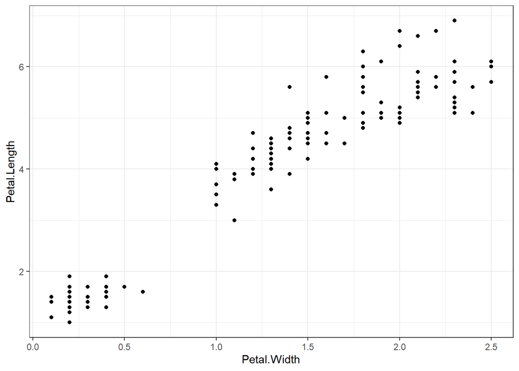

```r
#install.packages("tidyverse") #Remove the # if you haven't already installed the relevant package, tidyverse. It might take awhile.
library(ggplot2)
#ggplot(iris, aes(y=Petal.Length, x= Petal.Width))+ geom_point() #basic plot of the two variables.
#The geom_point parameter is used to make scatter plots, but you can change it according to the kind of graph you want to generate.
ggplot(iris, aes(y=Petal.Length, x= Petal.Width))+ geom_point() + theme_bw() #the theme_bw changes the color scheme of the figure and makes it not ugly anymore!
```

And now let’s add our regression trend line to the scatter plot. The code below adds the geom_smooth() layer to overlay a regression line onto the plot. This is probably close to the graphs you will use in seminar papers: data points and a regression line.

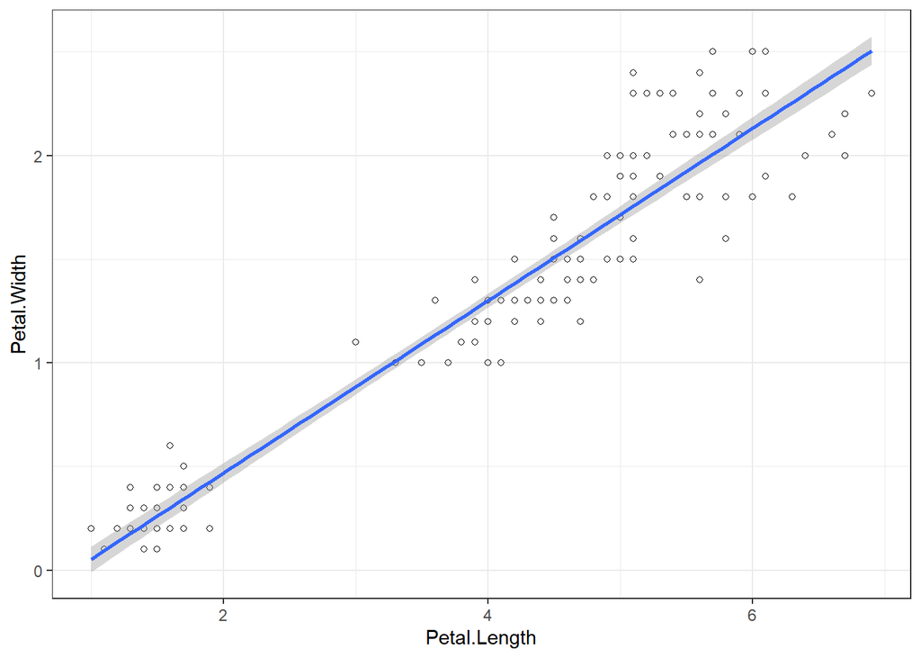

```r
ggplot(iris, aes(y= Petal.Width, x= Petal.Length)) + geom_point(shape=1) + theme_bw() +
  geom_smooth(method="lm", formula=y~x)
```

*Look at that beautiful linearity!*

### Practice

Replace the relevant portions of the below code to generate a new figure, this time using Sepal.Width and Sepal.Length. Are you bold enough to try adding axis labels?

```r
#ggplot(iris, aes(y= Some.Width, x= Some.Length)) + geom_point(shape=1) + theme_bw() +
#  geom_smooth(method="what does lm stand for?", formula=y*x) # formula?
```

### 3.2 Coefficient Plots

Regression results can also be conveyed using coefficient plots. These plots are more intuitive and easier to quickly interpret than regression tables, making them especially great for presentations. To do this we’ll be using a new package, sjPlot, in conjunction with the ‘plot model’ command. Plotting coefficients of bivariate relationships is kind of uninteresting, so we’ll add in some additional independent variables. The inclusion of these variables into a regression model will more closely resemble the work you’ll do in the future.

```r
#library(ggplot2) #just in case
#install.packages("sjPlot") #more packages! Go get a snack
library(sjPlot)
```

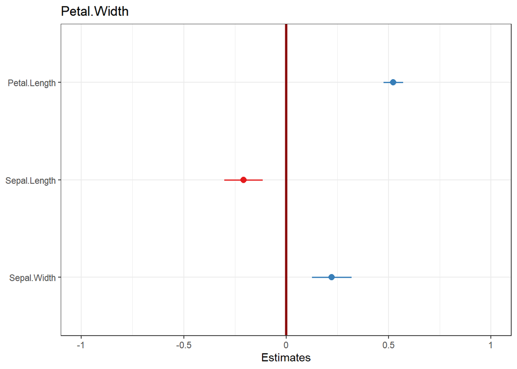

```r
#estimating a new linear regression with the additional independent variables
fit2 <- lm(Petal.Width~Petal.Length+Sepal.Length+Sepal.Width, data=iris)

#plotting the coefficients of the new linear model we made, fit2
plot_model(fit2,vline.color = "darkred") + theme_bw()
```

What does this graphic summary of the three regression coefficients tell us? Using petal width as our outcome variable, we can see that the coefficients of all three causal variables are distinguishable from zero. This means that they have *some* effect on our outcome of interest. Their standard deviation lines do not touch the vertical zero line, indicating that the results are statistically significant. And we can see that the direction of effect is different only with the `Sepal.Length,’ variable, which is alone in its negative association with petal width. So we get a lot of useful information from a single plot!

### Practice

There are many built in datasets provided with R. Let’s use one to create a different coefficient plot.

```r
#use the dataset mpg, and look at it:
#help(mpg)
colnames(mpg)
```

```
##  [1] "manufacturer" "model"        "displ"        "year"
##  [5] "cyl"          "trans"        "drv"          "cty"
##  [9] "hwy"          "fl"           "class"
```

```r
str(mpg)
```

```
## tibble [234 x 11] (S3: tbl_df/tbl/data.frame)
##  $ manufacturer: chr [1:234] "audi" "audi" "audi" "audi" ...
##  $ model       : chr [1:234] "a4" "a4" "a4" "a4" ...
##  $ displ       : num [1:234] 1.8 1.8 2 2 2.8 2.8 3.1 1.8 1.8 2 ...
##  $ year        : int [1:234] 1999 1999 2008 2008 1999 1999 2008 1999 1999 2008 ...
##  $ cyl         : int [1:234] 4 4 4 4 6 6 6 4 4 4 ...
##  $ trans       : chr [1:234] "auto(l5)" "manual(m5)" "manual(m6)" "auto(av)" ...
##  $ drv         : chr [1:234] "f" "f" "f" "f" ...
##  $ cty         : int [1:234] 18 21 20 21 16 18 18 18 16 20 ...
##  $ hwy         : int [1:234] 29 29 31 30 26 26 27 26 25 28 ...
##  $ fl          : chr [1:234] "p" "p" "p" "p" ...
##  $ class       : chr [1:234] "compact" "compact" "compact" "compact" ...
```

```r
# first create a regression model of your choice. Using cty as your outcome variable, choose three causal variables to place in the IV slots:
#fit3 <- lm(cty ~ Your_IV1 + Your_IV2 + Your_IV3, data=mpg)

# Now, create a coefficient plot!
#plot_model(fit3,vline.color = "gray80") + theme_bw()
```

## Wrap-up

In this section we discussed visualizing data using R, focusing on showing the distribution and spread of the dataset as well as displaying regression results. I shared certain commands, functions, and packages that I think will be especially useful for you and that many graduate students use in our research. Because this Rmarkdown document includes only the basic steps of visualization, I recommend visiting the following websites if you wish to learn more about the options available to you.

### References:

- Top 50 ggplot2: http://r-statistics.co/Top50-Ggplot2-Visualizations-MasterList-R-Code.html
- Color customization in ggplot2: http://www.sthda.com/english/wiki/ggplot2-colors-how-to-change-colors-automatically-and-manually
- US map: https://cran.r-project.org/web/packages/usmap/vignettes/mapping.html